[figure not shown]

# Missing Value Imputation Using MICE

## Background

The problem of missing value is quite common in many real-life datasets. Missing value can bias the results of the machine learning models and/or reduce the accuracy of the model. Missing value imputation (MVI) is the solution method most commonly used to deal with the incomplete dataset problem. In general, MVI is a process in which some statistical or machine learning techniques are used to replace the missing data with substituted values. However, the main limitation of using statistical imputation with measures of central tendency is that it leads to biased estimates of variance and covariance. Therefore, techniques with machine learning emerged as another alternative to overcome the weaknesses of statistical methods. One of the machine learning algorithms in the imputation technique is MICE.

## Multiple Imputation by Chained Equations (MICE)

**MICE (Multiple Imputation by Chained Equations)** is multiple imputation which is recognized as a leading strategy for inserting missing data due to its ease of implementation and ability to maintain unbiased effect estimates and valid inferences [(Ref)](https://onlinelibrary.wiley.com/doi/10.1002/sim.8468). So, MICE performs multiple regression for imputing.

MICE is a method of multiple imputation where missing values are filled in several times to create a complete data set. MICE is an imputation method that works with the assumption that the missing data is **Missing at Random (MAR)**. This means that the missing data properties are related to the observed data but not the missing data. So that the imputation process involves information from other observation columns. The MICE algorithm works by running a multiple regression model and each missing value is modeled conditionally depending on the observed (not missing) value.

The main characteristic of MICE is that it performs multiple imputations using a chained equations approach. Multiple Imputations is able to take into account statistical uncertainty in imputation. While the chain equation approach is very flexible and can handle variables of various types (continuous or binary).

The following are the steps of the MICE technique:

**Step 1**: All missing values are initially filled in by the usual statistical methods (eg mean for numeric, mode for categorical). This imputation can be considered a "place holders" (temporary value).

**Step 2:** Gradually, one by one column will be returned to NA. Set back to missing starts on the variable (“var”) with the least number of missing values.

**Step 3:** “var” is the dependent variable in the regression/classification model and all other variables are independent variables in the regression model.

**Step 4:** The missing values for “var” are then replaced with predictions (imputations) from the regression model. When "var" is subsequently used as an independent variable in a regression model for another variable, both this observed value and the calculated value will be used.

**Step 5:** Move to the next variable with the next fewest missing values, repeating steps 2–4 then for each variable that has missing data. Cycle through each variable constitutes one iteration or "cycle." At the end of one cycle, all missing values have been replaced with predictions from the regression that reflect the observed relationships in the data. The idea is that at the end of the cycle, the distribution of parameters governing imputation (eg, coefficients in a regression model) should converge in the sense of being stable.

Based on its performance, this MICE builds the potential of the imputation method which is able to produce predictive values that are closer to the original value. However, examining the strength of the techniques is important to help understand its characteristics.

## Libraries

```python
#Panda
import pandas as pd
import numpy as np

#Visualization
import matplotlib.pyplot as plt
import seaborn as sns

#random
import random

#SKLearn
from sklearn.experimental import enable_iterative_imputer
from sklearn.impute import IterativeImputer
from sklearn.metrics import mean_squared_error
from sklearn.metrics import accuracy_score
```

## Read Data

Took the data from Kaggle https://www.kaggle.com/code/nezarabdilahprakasa/resign-prediction-accuracy-92/data?select=Train.csv

```python
# read data
household = pd.read_csv("data/Train.csv", index_col=0)
household.head()
```

| Employee_ID | Gender | Age | Education_Level | Relationship_Status | Hometown | Unit | Decision_skill_possess | Time_of_service | Time_since_promotion | growth_rate | ... | Compensation_and_Benefits | Work_Life_balance | VAR1 | VAR2 | VAR3 | VAR4 | VAR5 | VAR6 | VAR7 | Attrition_rate |
| --- | --- | --- | --- | --- | --- | --- | --- | --- | --- | --- | --- | --- | --- | --- | --- | --- | --- | --- | --- | --- | --- |
| EID_23371 | F | 42.0 | 4 | Married | Franklin | IT | Conceptual | 4.0 | 4 | 33 | ... | type2 | 3.0 | 4 | 0.7516 | 1.8688 | 2.0 | 4 | 5 | 3 | 0.1841 |
| EID_18000 | M | 24.0 | 3 | Single | Springfield | Logistics | Analytical | 5.0 | 4 | 36 | ... | type2 | 4.0 | 3 | -0.9612 | -0.4537 | 2.0 | 3 | 5 | 3 | 0.0670 |
| EID_3891 | F | 58.0 | 3 | Married | Clinton | Quality | Conceptual | 27.0 | 3 | 51 | ... | type2 | 1.0 | 4 | -0.9612 | -0.4537 | 3.0 | 3 | 8 | 3 | 0.0851 |
| EID_17492 | F | 26.0 | 3 | Single | Lebanon | Human Resource Management | Behavioral | 4.0 | 3 | 56 | ... | type2 | 1.0 | 3 | -1.8176 | -0.4537 | NaN | 3 | 7 | 3 | 0.0668 |
| EID_22534 | F | 31.0 | 1 | Married | Springfield | Logistics | Conceptual | 5.0 | 4 | 62 | ... | type3 | 3.0 | 1 | 0.7516 | -0.4537 | 2.0 | 2 | 8 | 2 | 0.1827 |

5 rows × 23 columns

## Exploratory Data Analysis

```python
#Checking the type of the data
household.dtypes
```

```
Gender                        object
Age                          float64
Education_Level                int64
Relationship_Status           object
Hometown                      object
Unit                          object
Decision_skill_possess        object
Time_of_service              float64
Time_since_promotion           int64
growth_rate                    int64
Travel_Rate                    int64
Post_Level                     int64
Pay_Scale                    float64
Compensation_and_Benefits     object
Work_Life_balance            float64
VAR1                           int64
VAR2                         float64
VAR3                         float64
VAR4                         float64
VAR5                           int64
VAR6                           int64
VAR7                           int64
Attrition_rate               float64
dtype: object
```

```python
#Adjust the type of the columns
cat = household.select_dtypes('object').columns
cat
```

```
Index(['Gender', 'Relationship_Status', 'Hometown', 'Unit',
       'Decision_skill_possess', 'Compensation_and_Benefits'],
      dtype='object')
```

```python
# Adjust data type
household[cat] = household[cat].astype('category')
household.dtypes
```

```
Gender                       category
Age                           float64
Education_Level                 int64
Relationship_Status          category
Hometown                     category
Unit                         category
Decision_skill_possess       category
Time_of_service               float64
Time_since_promotion            int64
growth_rate                     int64
Travel_Rate                     int64
Post_Level                      int64
Pay_Scale                     float64
Compensation_and_Benefits    category
Work_Life_balance             float64
VAR1                            int64
VAR2                          float64
VAR3                          float64
VAR4                          float64
VAR5                            int64
VAR6                            int64
VAR7                            int64
Attrition_rate                float64
dtype: object
```

```python
household.head()
```

| Employee_ID | Gender | Age | Education_Level | Relationship_Status | Hometown | Unit | Decision_skill_possess | Time_of_service | Time_since_promotion | growth_rate | ... | Compensation_and_Benefits | Work_Life_balance | VAR1 | VAR2 | VAR3 | VAR4 | VAR5 | VAR6 | VAR7 | Attrition_rate |
| --- | --- | --- | --- | --- | --- | --- | --- | --- | --- | --- | --- | --- | --- | --- | --- | --- | --- | --- | --- | --- | --- |
| EID_23371 | F | 42.0 | 4 | Married | Franklin | IT | Conceptual | 4.0 | 4 | 33 | ... | type2 | 3.0 | 4 | 0.7516 | 1.8688 | 2.0 | 4 | 5 | 3 | 0.1841 |
| EID_18000 | M | 24.0 | 3 | Single | Springfield | Logistics | Analytical | 5.0 | 4 | 36 | ... | type2 | 4.0 | 3 | -0.9612 | -0.4537 | 2.0 | 3 | 5 | 3 | 0.0670 |
| EID_3891 | F | 58.0 | 3 | Married | Clinton | Quality | Conceptual | 27.0 | 3 | 51 | ... | type2 | 1.0 | 4 | -0.9612 | -0.4537 | 3.0 | 3 | 8 | 3 | 0.0851 |
| EID_17492 | F | 26.0 | 3 | Single | Lebanon | Human Resource Management | Behavioral | 4.0 | 3 | 56 | ... | type2 | 1.0 | 3 | -1.8176 | -0.4537 | NaN | 3 | 7 | 3 | 0.0668 |
| EID_22534 | F | 31.0 | 1 | Married | Springfield | Logistics | Conceptual | 5.0 | 4 | 62 | ... | type3 | 3.0 | 1 | 0.7516 | -0.4537 | 2.0 | 2 | 8 | 2 | 0.1827 |

5 rows × 23 columns

## Correlation Check

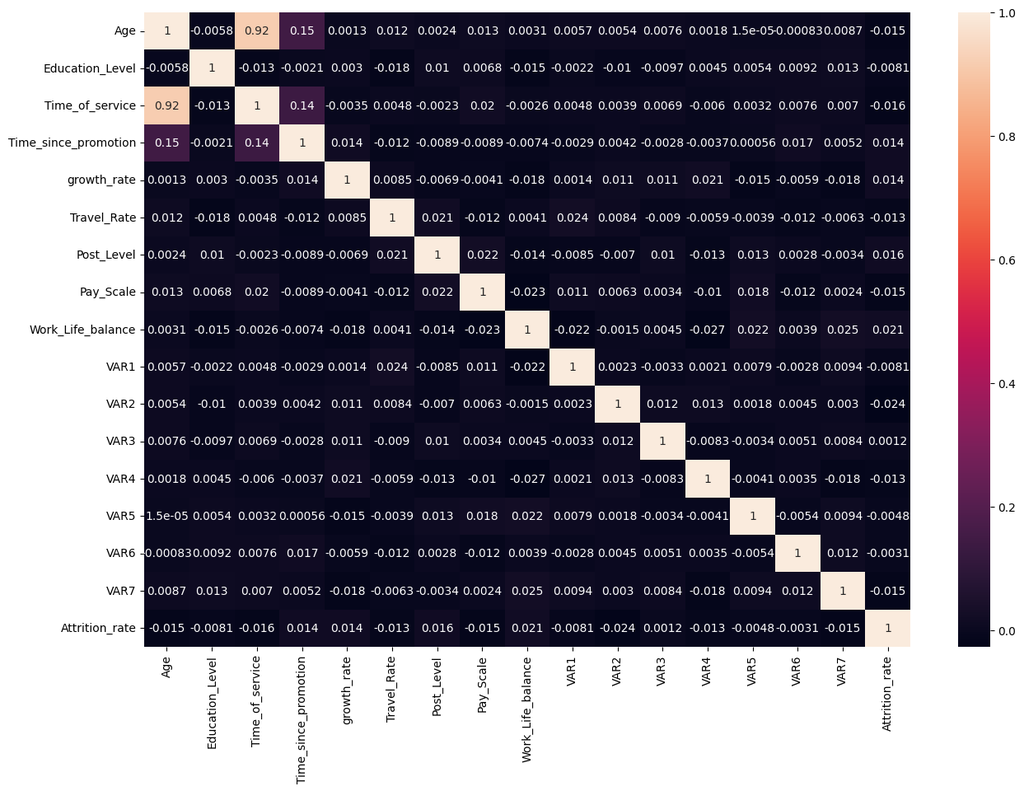

```python
#Correlation matrix
household.corr()

#Correlation heatmap
plt.figure(figsize=(15,10))
sns.heatmap(household.corr(), annot = True)
```

It seen that all the correlation (Excluding Age and Time Service) are low

## Check Missing Value

```python
household.isnull().sum()
```

```
Gender                         0
Age                          412
Education_Level                0
Relationship_Status            0
Hometown                       0
Unit                           0
Decision_skill_possess         0
Time_of_service              144
Time_since_promotion           0
growth_rate                    0
Travel_Rate                    0
Post_Level                     0
Pay_Scale                      9
Compensation_and_Benefits      0
Work_Life_balance             11
VAR1                           0
VAR2                         577
VAR3                           0
VAR4                         656
VAR5                           0
VAR6                           0
VAR7                           0
Attrition_rate                 0
dtype: int64
```

```python
#drop missing value
household_full = household.dropna()
```

```python
household_full.isna().sum()
```

```
Gender                       0
Age                          0
Education_Level              0
Relationship_Status          0
Hometown                     0
Unit                         0
Decision_skill_possess       0
Time_of_service              0
Time_since_promotion         0
growth_rate                  0
Travel_Rate                  0
Post_Level                   0
Pay_Scale                    0
Compensation_and_Benefits    0
Work_Life_balance            0
VAR1                         0
VAR2                         0
VAR3                         0
VAR4                         0
VAR5                         0
VAR6                         0
VAR7                         0
Attrition_rate               0
dtype: int64
```

## Label Encoding for Category Variables

Using `Decision Skill Possess` category column to be documented for checking the changing of value

```python
# check unique value of gender
#household_full.Gender.unique()
```

```python
#encode withn cat codes
#household_full['Gender'] = household_full['Gender'].cat.codes
```

```python
def cat_codes(df):
    for col in df.select_dtypes(include='category').columns:
        df[col] = df[col].cat.codes
```

```python
# call the function of cat_codes
cat_codes(household_full)
```

## Artificially Create Missing Value

```python
household_mv = household_full.copy()

random.seed(123)

ix = [(row, col) for row in range(household_mv.shape[0]) for col in range(household_mv.shape[1])]
for row, col in random.sample(ix, int(round(.1*len(ix)))):
    if (col ==  6) | (col ==  7) | (col ==  14) :
        household_mv.iat[row, col] = np.nan
```

## Check Artificial Missing Value

```python
## code here
household_mv.isnull().sum()
```

```
Gender                         0
Age                            0
Education_Level                0
Relationship_Status            0
Hometown                       0
Unit                           0
Decision_skill_possess       536
Time_of_service              529
Time_since_promotion           0
growth_rate                    0
Travel_Rate                    0
Post_Level                     0
Pay_Scale                      0
Compensation_and_Benefits      0
Work_Life_balance            558
VAR1                           0
VAR2                           0
VAR3                           0
VAR4                           0
VAR5                           0
VAR6                           0
VAR7                           0
Attrition_rate                 0
dtype: int64
```

```python
# copy household_mice
household_mice = household_mv.copy()
```

```python
## initiation
mice_imputer = IterativeImputer()

#imputation
household_mice = pd.DataFrame(mice_imputer.fit_transform(household_mice), columns=household_mice.columns)
```

```python
household_mice[['Decision_skill_possess', 'Time_of_service', 'Work_Life_balance']] = round(household_mice[['Decision_skill_possess', 'Time_of_service', 'Work_Life_balance']])
```

```python
household_mice
```

|  | Gender | Age | Education_Level | Relationship_Status | Hometown | Unit | Decision_skill_possess | Time_of_service | Time_since_promotion | growth_rate | ... | Compensation_and_Benefits | Work_Life_balance | VAR1 | VAR2 | VAR3 | VAR4 | VAR5 | VAR6 | VAR7 | Attrition_rate |
| --- | --- | --- | --- | --- | --- | --- | --- | --- | --- | --- | --- | --- | --- | --- | --- | --- | --- | --- | --- | --- | --- |
| 0 | 0.0 | 42.0 | 4.0 | 0.0 | 1.0 | 2.0 | 2.0 | 4.0 | 4.0 | 33.0 | ... | 2.0 | 3.0 | 4.0 | 0.7516 | 1.8688 | 2.0 | 4.0 | 5.0 | 3.0 | 0.1841 |
| 1 | 1.0 | 24.0 | 3.0 | 1.0 | 3.0 | 3.0 | 0.0 | 5.0 | 4.0 | 36.0 | ... | 2.0 | 4.0 | 3.0 | -0.9612 | -0.4537 | 2.0 | 3.0 | 5.0 | 3.0 | 0.0670 |
| 2 | 0.0 | 58.0 | 3.0 | 0.0 | 0.0 | 8.0 | 2.0 | 27.0 | 3.0 | 51.0 | ... | 2.0 | 1.0 | 4.0 | -0.9612 | -0.4537 | 3.0 | 3.0 | 8.0 | 3.0 | 0.0851 |
| 3 | 0.0 | 31.0 | 1.0 | 0.0 | 3.0 | 3.0 | 1.0 | 5.0 | 4.0 | 62.0 | ... | 3.0 | 3.0 | 1.0 | 0.7516 | -0.4537 | 2.0 | 2.0 | 8.0 | 2.0 | 0.1827 |
| 4 | 1.0 | 54.0 | 3.0 | 0.0 | 2.0 | 7.0 | 2.0 | 19.0 | 1.0 | 21.0 | ... | 2.0 | 1.0 | 3.0 | -1.8176 | 1.8688 | 2.0 | 2.0 | 8.0 | 3.0 | 0.7613 |
| ... | ... | ... | ... | ... | ... | ... | ... | ... | ... | ... | ... | ... | ... | ... | ... | ... | ... | ... | ... | ... | ... |
| 5348 | 0.0 | 23.0 | 5.0 | 0.0 | 1.0 | 5.0 | 1.0 | 4.0 | 1.0 | 20.0 | ... | 3.0 | 2.0 | 1.0 | 0.7516 | -0.4537 | 2.0 | 3.0 | 7.0 | 3.0 | 0.7839 |
| 5349 | 0.0 | 44.0 | 1.0 | 0.0 | 2.0 | 9.0 | 0.0 | 16.0 | 2.0 | 59.0 | ... | 3.0 | 3.0 | 2.0 | -0.1048 | -2.7762 | 2.0 | 4.0 | 8.0 | 4.0 | 0.1055 |
| 5350 | 0.0 | 49.0 | 3.0 | 1.0 | 3.0 | 2.0 | 3.0 | 10.0 | 1.0 | 59.0 | ... | 2.0 | 2.0 | 2.0 | -0.1048 | -0.4537 | 2.0 | 4.0 | 8.0 | 3.0 | 0.7847 |
| 5351 | 0.0 | 47.0 | 3.0 | 0.0 | 4.0 | 10.0 | 1.0 | 24.0 | 1.0 | 21.0 | ... | 0.0 | 2.0 | 4.0 | 0.7516 | 1.8688 | 2.0 | 3.0 | 6.0 | 3.0 | 0.4162 |
| 5352 | 0.0 | 58.0 | 3.0 | 0.0 | 1.0 | 2.0 | 2.0 | 26.0 | 2.0 | 74.0 | ... | 2.0 | 3.0 | 3.0 | -0.1048 | -1.6150 | 3.0 | 4.0 | 5.0 | 3.0 | 0.0910 |

5353 rows × 23 columns

## Evaluation

```python
## code here
mean_squared_error(household_full.Time_of_service, household_mice.Time_of_service)
```

```
1.6674761815804222
```

```python
#accuracy_score(household_full.Work_Life_balance, household_mice.Work_Life_balance)
```

```python
accuracy_score(household_full.Decision_skill_possess, household_mice.Decision_skill_possess)
```

```
0.9243414907528489
```

## Impute the Original Dataset

Based on performance of the imputation, the results shown are quite good, so the next step is doing imputation to the original dataset.

Using MICE as a method to substitute/ fill the missing value.

```python
household_impute = household.copy()
```

### Data Preparation

- Label Encoding

```python
# label encoding for categorical dataset
cat_codes(household_impute)
```

```python
# check unique value from Decision Skill Possess after encoding
household_impute['Decision_skill_possess'].unique()
```

```
array([2, 0, 1, 3], dtype=int8)
```

## Impute using MICE

```python
# MICE Imputation using mice_imputer
household_impute = pd.DataFrame(mice_imputer.fit_transform(household_impute), columns=household_impute.columns)
```

```python
# rounding for categorical column
household_impute['Decision_skill_possess'] = round(household_impute['Decision_skill_possess'])
```

```python
household_impute.isna().sum()
```

```
Gender                       0
Age                          0
Education_Level              0
Relationship_Status          0
Hometown                     0
Unit                         0
Decision_skill_possess       0
Time_of_service              0
Time_since_promotion         0
growth_rate                  0
Travel_Rate                  0
Post_Level                   0
Pay_Scale                    0
Compensation_and_Benefits    0
Work_Life_balance            0
VAR1                         0
VAR2                         0
VAR3                         0
VAR4                         0
VAR5                         0
VAR6                         0
VAR7                         0
Attrition_rate               0
dtype: int64
```

## Replace Missing Values

Revert to original value if there is missing value in categorical column

```python
# create scale mapper education
cat_deci = dict(enumerate(household["Decision_skill_possess"].cat.categories))
```

```python
# revert code kembali ke nilai sebenarnya
household_impute['Decision_skill_possess'] = household_impute['Decision_skill_possess'].replace(cat_deci)
```

```python
# reset_index promotion (because we're using index_col when we read the data)
household = household.reset_index()
```

```python
# replace missing value columns
household['Age'] = household_impute['Age']
household['Decision_skill_possess'] = household_impute['Decision_skill_possess']
household['Time_of_service'] = household_impute['Time_of_service']
household['Work_Life_balance'] = household_impute['Work_Life_balance']
household['VAR2'] = household_impute['VAR2']
household['VAR4'] = household_impute['VAR4']
```

```python
# check again the missing value
household.isnull().sum()
```

```
Employee_ID                  0
Gender                       0
Age                          0
Education_Level              0
Relationship_Status          0
Hometown                     0
Unit                         0
Decision_skill_possess       0
Time_of_service              0
Time_since_promotion         0
growth_rate                  0
Travel_Rate                  0
Post_Level                   0
Pay_Scale                    9
Compensation_and_Benefits    0
Work_Life_balance            0
VAR1                         0
VAR2                         0
VAR3                         0
VAR4                         0
VAR5                         0
VAR6                         0
VAR7                         0
Attrition_rate               0
dtype: int64
```